# FCA and the GDSTM

## GDSTM Decorrelation

This document describes the use of the **FRESA.CAD::GDSTMDecorrelation()** function that runs the feature correlation analysis (**FCA**) algorithm.

This scrip uses FRESA.CAD and mlbench R packages:

```r
knitr::opts_chunk$set(collapse = TRUE, warning = FALSE, message = FALSE,comment = "#>")

library("FRESA.CAD")
library(mlbench)

op <- par(no.readonly = TRUE)
```

I’ll load the Sonar data set

```r
data("Sonar", package = "mlbench")
print(table(Sonar$Class))
```

```
  M   R
111  97
```

Setting some variables for downstream analysis

```r
studyName = "Sonar"
datasetframe <- Sonar
Outcome <- "Class"

trainFraction = 0.50
correlationThreshold = 0.6
featnames <- colnames(datasetframe)[colnames(datasetframe) != Outcome]
```

Setting the Training and Testing sets

```r
tb <- table(datasetframe[,Outcome])
classNames <- unique(datasetframe[,Outcome])

allrowClass <- datasetframe[,Outcome]
names(allrowClass) <- rownames(datasetframe)

trainsize <- trainFraction*min(tb);
trainSamples <- NULL;
for (theClass in classNames)
{
  classSample <- allrowClass[allrowClass == theClass]
  trainSamples <- c(trainSamples,names(classSample[sample(length(classSample),trainsize)]))
}


datasetframe_train <- datasetframe[trainSamples,]
testSamples <- !(rownames(datasetframe) %in% trainSamples)
datasetframe_test <- datasetframe[testSamples,]

outcomes <- datasetframe_train[,Outcome]

pander::pander(table(datasetframe[,Outcome]),caption="All")
```

All

| M | R |
| --- | --- |
| 111 | 97 |

```r
pander::pander(table(datasetframe_train[,Outcome]),caption="Training")
```

Training

| M | R |
| --- | --- |
| 48 | 48 |

```r
pander::pander(table(datasetframe_test[,Outcome]),caption="Testing")
```

Testing

| M | R |
| --- | --- |
| 63 | 49 |

## FCA with default parameters

The default parameters will compute the transformation matrix with a maximum correlation goal of 0.8 using fast matrix multiplication with Pearson correlation and linear models estimation.

Default Parameters: thr=0.80,method=“fast”,type=“LM”

```r
datasetframeDecor<-list();
decortype <- list();
system.time(datasetframeDecor[[1]] <- GDSTMDecorrelation(datasetframe_train))
```

user system elapsed 0.03 0.00 0.05

```r
decortype[[1]] <- "Default"
```

We can decorrelate the testing set using the predict function

```r
decor_test <- predictDecorrelate(datasetframeDecor[[1]],datasetframe_test)
```

## Heat maps of the correlation matrices

Here are the heat maps of the correlation matrices before and after decorrelation on the testing set

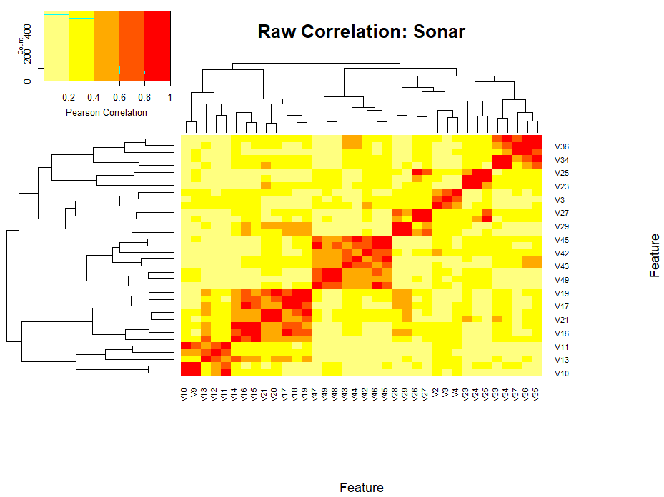

```r
featnames <- attr(datasetframeDecor[[1]],"varincluded")
cormat <- cor(datasetframe_test[,featnames],method="pearson")
gplots::heatmap.2(abs(cormat),
                  trace = "none",
                  scale = "none",
                  mar = c(10,10),
                  col=rev(heat.colors(5)),
                  main = paste("Raw Correlation:",studyName),
                  cexRow = 0.75,
                  cexCol = 0.75,
                  key.title=NA,
                  key.xlab="Pearson Correlation",
                  xlab="Feature", ylab="Feature")
```

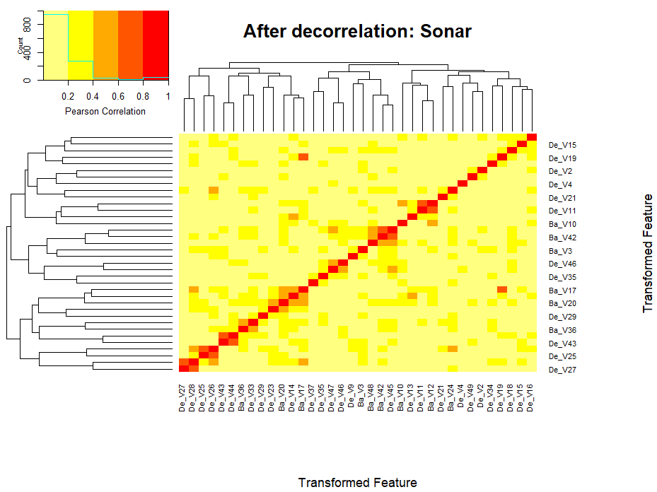

```r
featnames <- colnames(attr(datasetframeDecor[[1]],"GDSTM"))
cormat <- cor(decor_test[,featnames],method="pearson")
gplots::heatmap.2(abs(cormat),
                  trace = "none",
                  scale = "none",
                  mar = c(10,10),
                  col=rev(heat.colors(5)),
                  main = paste("After decorrelation:",studyName),
                  cexRow = 0.75,
                  cexCol = 0.75,
                  key.title=NA,
                  key.xlab="Pearson Correlation",
                  xlab="Transformed Feature", ylab="Transformed Feature")
```

```r
NA
NA
```

## FCA with Options

The following code runs the function and selecting some of the possible options:

```r
# Change the maximum correlation goal

decortype[[2]] <- "AtThr"
system.time(datasetframeDecor[[2]] <- GDSTMDecorrelation(
  datasetframe_train,
  thr = correlationThreshold
  ))
```

..no Fast..[ 1 ][ 1 ] user system elapsed 0.08 0.02 0.09

```r
# Change the maximum correlation goal, and set to Robust Liner Models
decortype[[3]] <- "RLM_Pearson"
system.time(datasetframeDecor[[3]] <- GDSTMDecorrelation(
  datasetframe_train,
  thr = correlationThreshold,
  type="RLM",
  method="pearson"))
```

user system elapsed 0.49 0.03 0.48

```r
# Change the maximum correlation goal, and change to Spearman correlation
decortype[[4]] <- "LM_Spearman"
system.time(datasetframeDecor[[4]] <- GDSTMDecorrelation(
  datasetframe_train,
  thr = correlationThreshold,
  type="LM",
  method="spearman"))
```

user system elapsed 0.12 0.05 0.13

```r
# Change the maximum correlation goal, and set Spearman correlation with robust liner model
decortype[[5]] <- "RLM_Spearman"
system.time(datasetframeDecor[[5]] <- GDSTMDecorrelation(
  datasetframe_train,
  thr = correlationThreshold,
  type="RLM",
  method="spearman"))
```

user system elapsed 0.36 0.02 0.38

```r
# The following are for supervised basis learning

# Set the target class for association learning
decortype[[6]] <- "Sup_Default"
system.time(datasetframeDecor[[6]] <- GDSTMDecorrelation(
  datasetframe_train,
  Outcome=Outcome))
```

user system elapsed 0.06 0.00 0.07

```r
# Change the maximum correlation goal
decortype[[7]] <- "Sup_AtThr"
system.time(datasetframeDecor[[7]] <- GDSTMDecorrelation(
  datasetframe_train,
  thr = correlationThreshold,
  Outcome=Outcome))
```

user system elapsed 0.09 0.03 0.10

```r
# Change the maximum correlation goal, and set to Robust Liner Models
decortype[[8]] <- "Sup_RLM_Pearson"
system.time(datasetframeDecor[[8]] <- GDSTMDecorrelation(
  datasetframe_train,
  thr = correlationThreshold,
  Outcome=Outcome,
  type="RLM",
  method="pearson"))
```

user system elapsed 0.47 0.00 0.48

```r
# Change the maximum correlation goal, and change to Spearman correlation
decortype[[9]] <- "Sup_LM_Spearman"
system.time(datasetframeDecor[[9]] <- GDSTMDecorrelation(
  datasetframe_train,
  thr = correlationThreshold,
  Outcome=Outcome,
  type="LM",
  method="spearman"))
```

user system elapsed 0.20 0.06 0.18

```r
# Change the maximum correlation goal, and set to Spearman correlation with robust liner model
decortype[[10]] <- "Sup_RLM_Spearman"
system.time(datasetframeDecor[[10]] <- GDSTMDecorrelation(
  datasetframe_train,
  thr = correlationThreshold,
  Outcome=Outcome,
  type="RLM",
  method="spearman"))
```

user system elapsed 0.39 0.00 0.39

```r
# With user defined supervised basis
decortype[[11]] <- "Sup_KS_RLM_Spearman"
baseKS <- names(univariate_KS(datasetframe_train,
                        Outcome=Outcome,
                        pvalue=0.20,
                        limit=0,
                        thr=correlationThreshold))

system.time(datasetframeDecor[[11]] <- GDSTMDecorrelation(
  datasetframe_train,
  thr = correlationThreshold,
  Outcome=Outcome,
  baseFeatures=baseKS,
  type="RLM",
  method="spearman"))
```

user system elapsed 0.36 0.00 0.36

The **GDSTMDecorrelation** function returns a data frame with the following column names:

The output features after transformation will be named after the original names and:

- The name will be unaltered if their maximum correlation to other features was lower than the threshold.
- The name will have the “Ba_” prefix is the feature was correlated but used as unaltered basis
- The name will have the “De_” prefix is the feature was original correlated and its correlation to “Ba_” features has been removed.

Furthermore, the returned data frame will have the following attributes:

1. Transformation matrix: “*GDSTM*”
2. Features:
   1. “*fsocre*”
   2. “*varincluded*”
   3. “*topFeatures*”
3. Unaltered Basis:
   1. “*baseFeatures*”
      1. “*correlatedToBase*”
   2. “*AbaseFeatures*”

### GDSTM

The “*GDSTM***“** attribute stores the spatial transformation matrix. The matrix only includes continuous features that had some correlation greater than the threshold

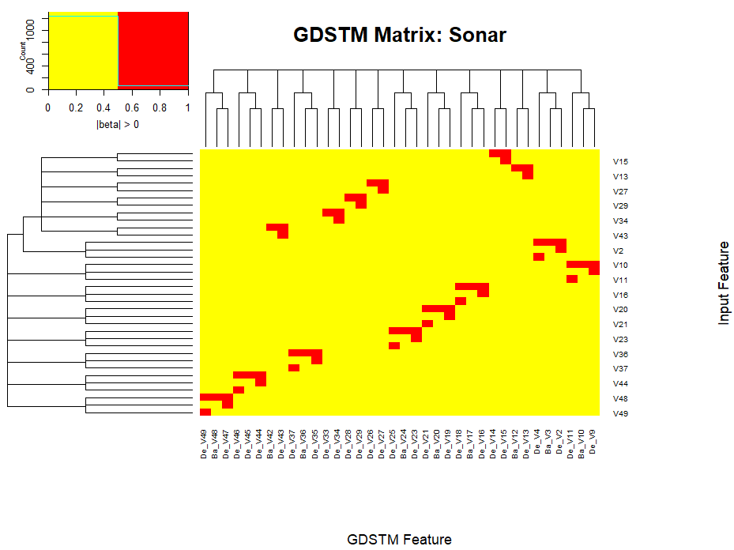

```r
## The Spatial Transformation Matrix:
GDSTM <- attr(datasetframeDecor[[1]],"GDSTM")

## The heatmap of the matrix
gplots::heatmap.2(1*(abs(GDSTM) > 0),
                  trace = "none",
                  mar = c(10,10),
                  col=rev(heat.colors(2)),
                  main = paste("GDSTM Matrix:",studyName),
                  cexRow = 0.7,
                  cexCol = 0.7,
                  breaks = c(0,0.5,1),
                  key.title=NA,
                  key.xlab="|beta| > 0",
                  xlab="GDSTM Feature", ylab="Input Feature")
```

```r
pander::pander(t(colnames(GDSTM)),caption="New names of decorrelated matrix")
```

New names of decorrelated matrix (continued below)

| De_V2 | Ba_V3 | De_V4 | De_V9 | Ba_V10 | De_V11 | Ba_V12 | De_V13 | De_V14 |
| --- | --- | --- | --- | --- | --- | --- | --- | --- |

Table continues below

| De_V15 | De_V16 | Ba_V17 | De_V18 | De_V19 | Ba_V20 | De_V21 | De_V23 | Ba_V24 |
| --- | --- | --- | --- | --- | --- | --- | --- | --- |

Table continues below

| De_V25 | De_V26 | De_V27 | De_V28 | De_V29 | De_V33 | De_V34 | De_V35 | Ba_V36 |
| --- | --- | --- | --- | --- | --- | --- | --- | --- |

| De_V37 | Ba_V42 | De_V43 | De_V44 | De_V45 | De_V46 | De_V47 | Ba_V48 | De_V49 |
| --- | --- | --- | --- | --- | --- | --- | --- | --- |

### Features analysis of the FCA algorithm

The **FCA** analysis of the data features are stored in three attributes: “*varincluded*”, “*topFeatures*”, and “*fscore*”.

- “varincluded” returns the list of continuous features that were decorrelated
- “topFeatures” returns the features that at some point were used as independent variables inside the linear models.
- “fscore” : returns a named vector with the total feature score, $F_j$, of the analyzed features.

$$F_j=∑_{n}∑_{i∈B^{n}_{j}}|ρ_{i,j}|^2(|ρ_{i,j}|>ρ_{th}),~ \forall j \in Ind$$

$$F_j=F_j-∑_{n}|ρ_{B^n_j,j}|^2),~ \forall j \in Dep$$

where $B^n_j$ is the set of features statistically associated with feature *j* at iteration *n,* $ρ_{i,j}$ is the correlation between features *i,j*, and $ρ_{th}$ is the correlation goal, ${Ind, Dep}$ are the set of independent and dependent features respectively. In other words, the “*fscore”* indicates the degree of total association of”independent” features to dependent features.

```r
pander::pander(t(attr(datasetframeDecor[[1]],"varincluded")),caption="Correlated Features")
```

Correlated Features (continued below)

| V2 | V3 | V4 | V9 | V10 | V11 | V12 | V13 | V14 | V15 | V16 | V17 | V18 | V19 |
| --- | --- | --- | --- | --- | --- | --- | --- | --- | --- | --- | --- | --- | --- |

Table continues below

| V20 | V21 | V23 | V24 | V25 | V26 | V27 | V28 | V29 | V33 | V34 | V35 | V36 |
| --- | --- | --- | --- | --- | --- | --- | --- | --- | --- | --- | --- | --- |

| V37 | V42 | V43 | V44 | V45 | V46 | V47 | V48 | V49 |
| --- | --- | --- | --- | --- | --- | --- | --- | --- |

```r
pander::pander(t(attr(datasetframeDecor[[1]],"topFeatures")),caption="Independent Features")
```

Independent Features

| V17 | V48 | V36 | V20 | V12 | V24 | V10 | V3 | V42 | V14 | V26 | V45 | V33 | V28 |
| --- | --- | --- | --- | --- | --- | --- | --- | --- | --- | --- | --- | --- | --- |

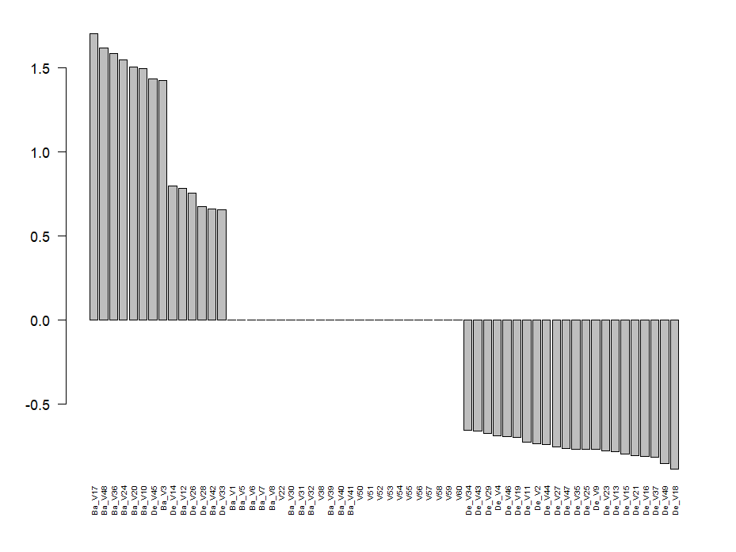

```r
fscore <- attr(datasetframeDecor[[1]],"fscore")
fscore <- fscore[order(-fscore)];
barplot(fscore,las=2,cex.names = 0.6)
```

The FCA algorithm will return for unsupervised basis learning the following attribute: “*AbaseFeatures*”

```r
pander::pander(t(attr(datasetframeDecor[[1]],"AbaseFeatures")),caption="Set of unaltered features")
```

Set of unaltered features (continued below)

| V17 | V48 | V36 | V20 | V12 | V24 | V10 | V3 | V42 | V39 | V30 | V31 | V32 |
| --- | --- | --- | --- | --- | --- | --- | --- | --- | --- | --- | --- | --- |

| V40 | V41 | V5 | V8 | V1 | V6 | V7 |
| --- | --- | --- | --- | --- | --- | --- |

The total set of unaltered features is:

```r
atbase <- attr(datasetframeDecor[[1]],"AbaseFeatures")
featnames <- colnames(datasetframe_train)
included <- attr(datasetframeDecor[[1]],"varincluded")

notinvarincluded <-  featnames[!(featnames %in% included)]
pander::pander(t(c(atbase,notinvarincluded)),caption="Set of unaltered features")
```

Set of unaltered features (continued below)

| V17 | V48 | V36 | V20 | V12 | V24 | V10 | V3 | V42 | V39 | V30 | V31 | V32 |
| --- | --- | --- | --- | --- | --- | --- | --- | --- | --- | --- | --- | --- |

Table continues below

| V40 | V41 | V5 | V8 | V1 | V6 | V7 | V1 | V5 | V6 | V7 | V8 | V22 | V30 | V31 |
| --- | --- | --- | --- | --- | --- | --- | --- | --- | --- | --- | --- | --- | --- | --- |

Table continues below

| V32 | V38 | V39 | V40 | V41 | V50 | V51 | V52 | V53 | V54 | V55 | V56 | V57 |
| --- | --- | --- | --- | --- | --- | --- | --- | --- | --- | --- | --- | --- |

| V58 | V59 | V60 | Class |
| --- | --- | --- | --- |

For supervised basis learning the FCA algorithm will return the following attributes:

- “*baseFeatures*” and “*correlatedToBase*”

The “*baseFeatures*” is the set of features that the **FRESA.CAD::univariate_correlation()** univariate filter function used to get the features associated with the outcome.

```r
# With Supervised Basis

pander::pander(t(attr(datasetframeDecor[[6]],"baseFeatures")),caption="Set of unaltered features")
```

Set of unaltered features

| V11 | V12 | V36 | V35 | V20 | V45 | V49 | V1 | V44 | V4 | V34 | V43 | V5 | V46 | V3 |
| --- | --- | --- | --- | --- | --- | --- | --- | --- | --- | --- | --- | --- | --- | --- |

```r
if (length(attr(datasetframeDecor[[6]],"correlatedToBase"))>0)
{
pander::pander(t(attr(datasetframeDecor[[6]],"correlatedToBase")),caption="Set of features associated with base")
}
```

Set of features associated with base

| V2 | V13 | V19 | V21 | V33 | V37 | V42 | V47 | V48 |
| --- | --- | --- | --- | --- | --- | --- | --- | --- |

```r
atbaseSup <- attr(datasetframeDecor[[6]],"baseFeatures")
included <- attr(datasetframeDecor[[6]],"varincluded")

notinvarincludedSup <-  featnames[!(featnames %in% included)]
pander::pander(t(c(atbaseSup,notinvarincludedSup)),caption="Set of unaltered features: Supervised")
```

Set of unaltered features: Supervised (continued below)

| V11 | V12 | V36 | V35 | V20 | V45 | V49 | V1 | V44 | V4 | V34 | V43 | V5 | V46 |
| --- | --- | --- | --- | --- | --- | --- | --- | --- | --- | --- | --- | --- | --- |

Table continues below

| V3 | V1 | V5 | V6 | V7 | V8 | V22 | V30 | V31 | V32 | V38 | V39 | V40 | V41 |
| --- | --- | --- | --- | --- | --- | --- | --- | --- | --- | --- | --- | --- | --- |

| V44 | V50 | V51 | V52 | V53 | V54 | V55 | V56 | V57 | V58 | V59 | V60 | Class |
| --- | --- | --- | --- | --- | --- | --- | --- | --- | --- | --- | --- | --- |

```r
pander::pander(t(c(atbase,notinvarincluded)),caption="Set of unaltered features: Unsupervised")
```

Set of unaltered features: Unsupervised (continued below)

| V17 | V48 | V36 | V20 | V12 | V24 | V10 | V3 | V42 | V39 | V30 | V31 | V32 |
| --- | --- | --- | --- | --- | --- | --- | --- | --- | --- | --- | --- | --- |

Table continues below

| V40 | V41 | V5 | V8 | V1 | V6 | V7 | V1 | V5 | V6 | V7 | V8 | V22 | V30 | V31 |
| --- | --- | --- | --- | --- | --- | --- | --- | --- | --- | --- | --- | --- | --- | --- |

Table continues below

| V32 | V38 | V39 | V40 | V41 | V50 | V51 | V52 | V53 | V54 | V55 | V56 | V57 |
| --- | --- | --- | --- | --- | --- | --- | --- | --- | --- | --- | --- | --- |

| V58 | V59 | V60 | Class |
| --- | --- | --- | --- |

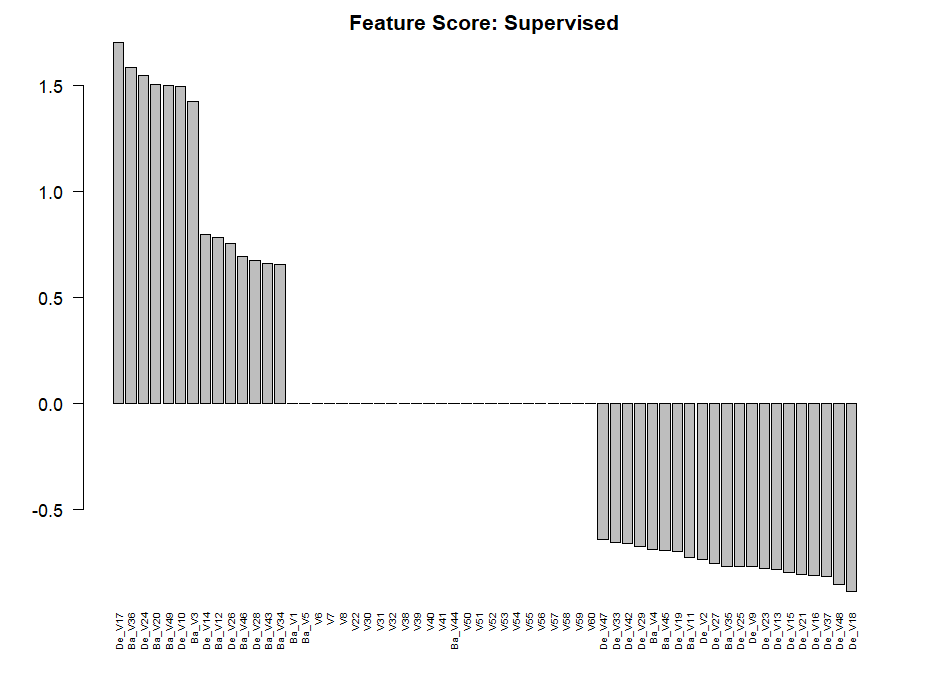

```r
fscore <- attr(datasetframeDecor[[6]],"fscore")
fscore <- fscore[order(-fscore)];
barplot(fscore,las=2,cex.names = 0.6,main="Feature Score: Supervised")
```

## Machine Learning and GDSTM

Train a simple NB model on the raw dataset

In FRESA.CAD all Binary classification task assume that the outcome is 0 and 1.

```r
datasetframe_train[,Outcome] <- 1*(datasetframe_train[,Outcome] == classNames[2])

mNBRaw <- filteredFit(paste(Outcome,"~."),
                   datasetframe_train,
                   fitmethod=NAIVE_BAYES,
                     filtermethod=univariate_Wilcoxon,
                     filtermethod.control=list(pvalue=0.05,limit= 0.2),
                     Scale="OrderLogit",
                     pca=FALSE
                   )

# With PCA
mNBPCA <- filteredFit(paste(Outcome,"~."),
                   datasetframe_train,
                   fitmethod=NAIVE_BAYES,
                     filtermethod=univariate_Wilcoxon,
                     filtermethod.control=list(pvalue=0.05,limit= 0.2),
                     Scale="OrderLogit",
                     pca=TRUE
                   )
```

Now using the decorrelated data

```r
datasetframeDecor[[1]][,Outcome] <- 1*(datasetframeDecor[[1]][,Outcome] == classNames[2])

mNBDecor <- filteredFit(paste(Outcome,"~."),
                   datasetframeDecor[[1]],
                    fitmethod=NAIVE_BAYES,
                     filtermethod=univariate_Wilcoxon,
                     filtermethod.control=list(pvalue=0.05,limit= 0.2),
                     Scale="OrderLogit",
                     pca=FALSE
                   )
```

Selected Raw Feattures

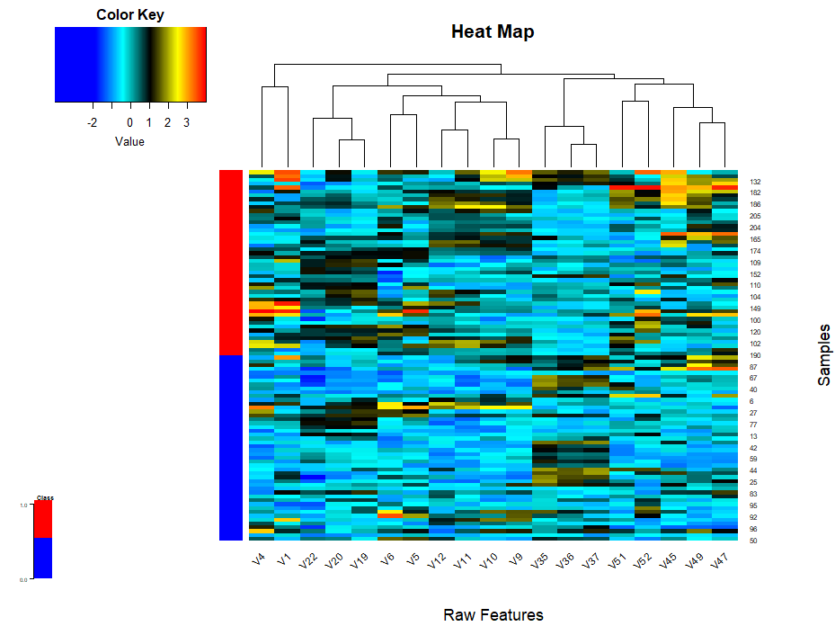

```r
vnames <- as.data.frame(cbind(mNBRaw$selectedfeatures,mNBRaw$selectedfeatures))
dta <- datasetframe_train;
dta <- FRESAScale(dta,method="OrderLogit")$scaledData
dta$Class <- as.numeric(dta$Class)
hm <- heatMaps(variableList=vnames,
               data=dta,
               Outcome=Outcome,
               hCluster="col",
               srtCol=45,
               xlab="Raw Features",
               ylab="Samples"
               )
```

Selected decorrelated Features

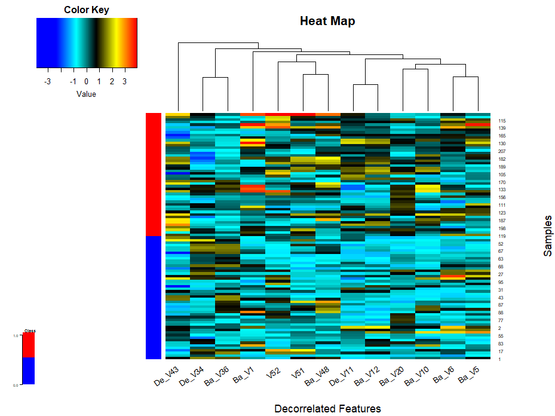

```r
vnames <- as.data.frame(cbind(mNBDecor$selectedfeatures,mNBDecor$selectedfeatures))
dta <- datasetframeDecor[[1]];
dta <- FRESAScale(dta,method="OrderLogit")$scaledData
dta$Class <- as.numeric(dta$Class)
hm <- heatMaps(variableList=vnames,
               data=dta,
               Outcome=Outcome,
               hCluster="col",
               srtCol=35,
               xlab="Decorrelated Features",
               ylab="Samples"
               )
```

To make predictions we need to transform the testing set. This is done using the **FRESA.CAD::predictDecorrelate()** function

```r
# Transform the testing set

datasetframe_test[,Outcome] <- 1*(datasetframe_test[,Outcome] == classNames[2])

decor_test <- predictDecorrelate(datasetframeDecor[[1]],datasetframe_test)
```

Once we have the transformed testing dataset we can make a side by side comparison of predictions

```r
# Predict the raw testing set
prRAW <- predict(mNBRaw,datasetframe_test)

# Predict with PCA
prPCA <- predict(mNBPCA,datasetframe_test)

# Predict the transformed dataset
prDecor <- predict(mNBDecor,decor_test)


par(mfrow=c(1,3))
meanROCAUC <- numeric(3);
meanPCAROCAUC <- numeric(3);
{
  classoutcomes <- datasetframe_test[,Outcome]
  psRaw <- predictionStats_binary(cbind(classoutcomes,prRAW),
                                "Raw",cex=0.75)
  pander::pander(psRaw$aucs)
  psPCA <- predictionStats_binary(cbind(classoutcomes,prPCA),
                                "PCA :",cex=0.75)
  pander::pander(psPCA$aucs)
  psDecor <- predictionStats_binary(cbind(classoutcomes,prDecor),
                                "GDSTM :",cex=0.75)
  pander::pander(psDecor$aucs)
  meanROCAUC <- meanROCAUC + psRaw$aucs;
  meanPCAROCAUC <- meanPCAROCAUC + psPCA$aucs;
}
```

Raw

| est | lower | upper |
| --- | --- | --- |
| 0.8759 | 0.8062 | 0.9457 |

PCA :

| est | lower | upper |
| --- | --- | --- |
| 0.645 | 0.5385 | 0.7514 |

GDSTM :

| est | lower | upper |
| --- | --- | --- |
| 0.8662 | 0.7982 | 0.9342 |

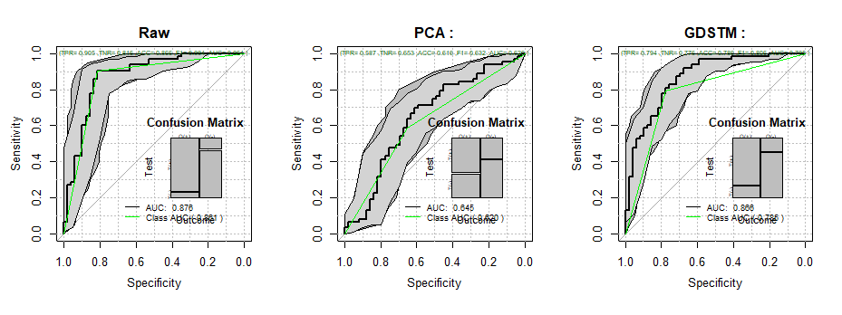

```r
meanROCAUC <- meanROCAUC
AllRocAUC <- meanROCAUC;
meanPCAROCAUC <- meanPCAROCAUC
AllRocAUC <- rbind(AllRocAUC,meanPCAROCAUC);
```

## Predict All Decorrelations

```r
par(mfrow=c(2,2))

for (i in c(1:length(datasetframeDecor)))
{
  if (i > 1)
  {
     datasetframeDecor[[i]][,Outcome] <- 1*(datasetframeDecor[[i]][,Outcome] == classNames[2])
  }
  mNBDecor <- filteredFit(paste(Outcome,"~."),
                   datasetframeDecor[[i]],
                    fitmethod=NAIVE_BAYES,
                     filtermethod=univariate_Wilcoxon,
                     filtermethod.control=list(pvalue=0.05,limit= 0.2),
                     Scale="OrderLogit",
                     pca=FALSE
                   )

  decor_test <- predictDecorrelate(datasetframeDecor[[i]],datasetframe_test)
  prDecor <- predict(mNBDecor,decor_test)
  meanROCAUC <- numeric(3);

    classoutcomes <- datasetframe_test[,Outcome]
    psDecor <- predictionStats_binary(cbind(classoutcomes,prDecor),
                                  decortype[[i]],cex=0.75)
    meanROCAUC <- meanROCAUC + psDecor$aucs;
  meanROCAUC <- meanROCAUC
  pander::pander(meanROCAUC)
  AllRocAUC <- rbind(AllRocAUC,meanROCAUC)
}
```

Default

| est | lower | upper |
| --- | --- | --- |
| 0.8662 | 0.7982 | 0.9342 |

AtThr

| est | lower | upper |
| --- | --- | --- |
| 0.8435 | 0.7663 | 0.9208 |

RLM_Pearson

| est | lower | upper |
| --- | --- | --- |
| 0.8413 | 0.7651 | 0.9174 |

LM_Spearman

| est | lower | upper |
| --- | --- | --- |
| 0.8707 | 0.8044 | 0.9371 |

RLM_Spearman

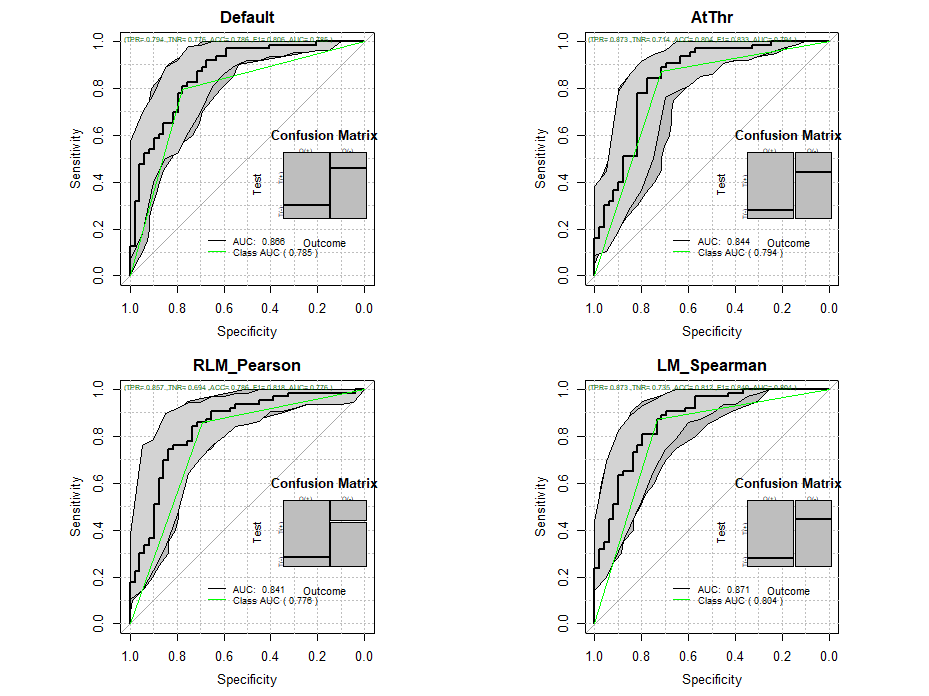

| est | lower | upper |
| --- | --- | --- |
| 0.8594 | 0.7898 | 0.929 |

Sup_Default

| est | lower | upper |
| --- | --- | --- |
| 0.8422 | 0.7686 | 0.9159 |

Sup_AtThr

| est | lower | upper |
| --- | --- | --- |
| 0.7949 | 0.712 | 0.8779 |

Sup_RLM_Pearson

| est | lower | upper |
| --- | --- | --- |
| 0.8173 | 0.7383 | 0.8963 |

Sup_LM_Spearman

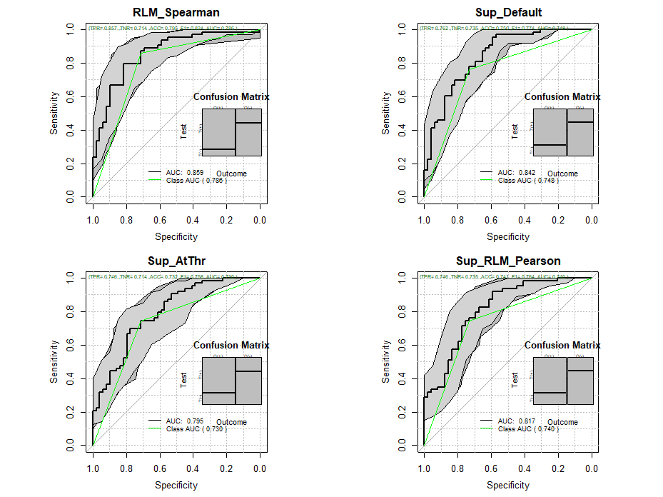

| est | lower | upper |
| --- | --- | --- |
| 0.8144 | 0.7354 | 0.8933 |

Sup_RLM_Spearman

| est | lower | upper |
| --- | --- | --- |
| 0.8157 | 0.7369 | 0.8944 |

Sup_KS_RLM_Spearman

| est | lower | upper |
| --- | --- | --- |
| 0.8364 | 0.7614 | 0.9114 |

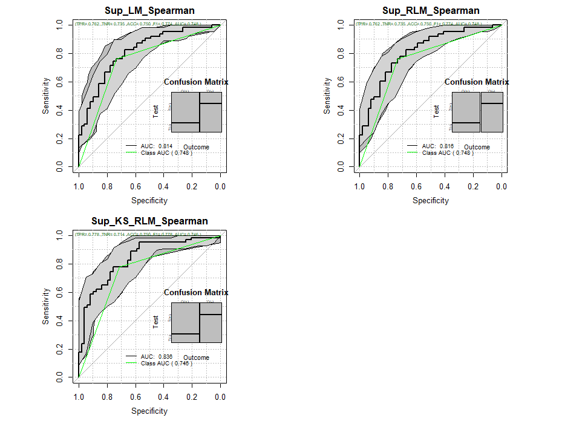

```r
rownames(AllRocAUC) <- c("Raw","PCA",unlist(decortype))
pander::pander(AllRocAUC)
```

|  | est | lower | upper |
| --- | --- | --- | --- |
| **Raw** | 0.8759 | 0.8062 | 0.9457 |
| **PCA** | 0.645 | 0.5385 | 0.7514 |
| **Default** | 0.8662 | 0.7982 | 0.9342 |
| **AtThr** | 0.8435 | 0.7663 | 0.9208 |
| **RLM_Pearson** | 0.8413 | 0.7651 | 0.9174 |
| **LM_Spearman** | 0.8707 | 0.8044 | 0.9371 |
| **RLM_Spearman** | 0.8594 | 0.7898 | 0.929 |
| **Sup_Default** | 0.8422 | 0.7686 | 0.9159 |
| **Sup_AtThr** | 0.7949 | 0.712 | 0.8779 |
| **Sup_RLM_Pearson** | 0.8173 | 0.7383 | 0.8963 |
| **Sup_LM_Spearman** | 0.8144 | 0.7354 | 0.8933 |
| **Sup_RLM_Spearman** | 0.8157 | 0.7369 | 0.8944 |
| **Sup_KS_RLM_Spearman** | 0.8364 | 0.7614 | 0.9114 |

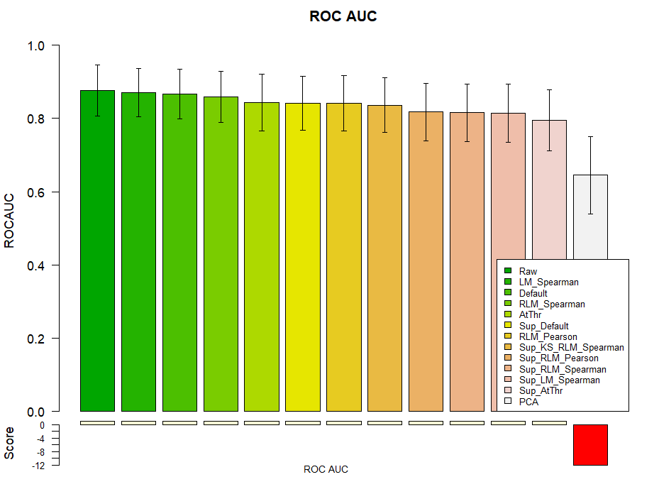

```r
bpROCAUC <- barPlotCiError(as.matrix(AllRocAUC),
                          metricname = "ROCAUC",
                          thesets = "ROC AUC",
                          themethod = rownames(AllRocAUC),
                          main = "ROC AUC",
                          offsets = c(0.5,1),
                          scoreDirection = ">",
                          ho=0.5,
                          args.legend = list(bg = "white",x="bottomright",inset=c(0.0,0),cex=0.75),
                          col = terrain.colors(nrow(AllRocAUC))
                          )
```